# Testing

--- Exploring the use of a Jupyter Notebook ---

```python
import pandas as pd
import seaborn as sns
import matplotlib as mpl
%matplotlib inline
#Needs to be in here to show graphs for seaborn
```

$$y=mx+b$$

LaTex nomeclature for equations

Okie doke, so let's see what we can do with some data. We're going to look at some public data linked from Data.gov, called CropScape, which shows the acreage of various agricultural vegetation grown in areas all around the US. I specifically localized the dataset to Colorado, and gathered all the crop acreage data for each year from 2008 to 2016. Let's start off by loading one of them to pandas and seeing what it looks like.

```python
col_crop_08_df = pd.read_csv('colorado_crop_acreage_data/cdl_2008_08.csv')
col_crop_08_df.head(3)
```

|  | Value | Category | Count | Acreage |
| --- | --- | --- | --- | --- |
| 0 | 176 | Grass/Pasture | 32163277 | 24924024.2 |
| 1 | 142 | Evergreen Forest | 19275611 | 14937091.0 |
| 2 | 152 | Shrubland | 14766733 | 11443063.2 |

Okie dokie, so it looks like each of these data files contain: 1. A 'Category' for what crop we're talking about 2. A 'Value' integer corresponding to the specific 'Category' 3. A 'Count' for the number of pixels in the data (CropScape uses Geospatial coordinates, these pixels correspond to the number of pixels in the dataset which directly corresponds to the next value 'Acreage'. 4. An 'Acreage' for the number of acres that 'Category' represents in Colorado for that Year. Let's try and use the python module 'Seaborn' to show the column comparison of Category to Acreage and produce a pretty pretty graph!

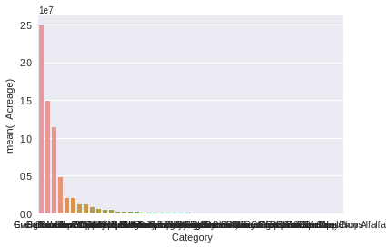

```python
col_crop_08_df_chart = col_crop_08_df[[' Category', '  Acreage']]
sns.barplot(x=' Category', y='  Acreage', data=col_crop_08_df_chart)
```

Ok, so 2 problems. 1. 'Category' is actually ' Category', and 'Acreage' is actually ' Acreage'. So need to keep this in mind in the future. 2. A lot of categories so the bar chart looks like garbage water. So we need to select only some, like maybe 8. So to figure out these 8, let's check out all the categories and logically pick some.

```python
col_crop_08_df[' Category']
```

```
0                   Grass/Pasture
1                Evergreen Forest
2                       Shrubland
3                Deciduous Forest
4            Fallow/Idle Cropland
5                    Winter Wheat
6                            Corn
7            Developed/Open Space
8                          Barren
9                         Alfalfa
10        Developed/Low Intensity
11                 Woody Wetlands
12                   Mixed Forest
13                     Open Water
14                         Millet
```

[output cut: 34 more lines]

Alright, so let's go with Tree crops. It won't be 8, but let's choose: Apples(46), Cherries(44), Peaches(38), and Other Tree Crops(45). That's 4. So let's make a list with our chosen categories by their (index) and grab out those categories.

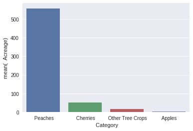

```python
col_crop_08_df_tree_fruits = col_crop_08_df.loc[[38,44,45,46]]
sns.barplot(x=' Category', y='  Acreage', data=col_crop_08_df_tree_fruits)
```

Ok, that looks decent. Turns out Peaches dominate the acreage market in Colorado in 2008. So, maybe next we should import the rest of the years, and see how these acreage values fluctuate through the years. To do this, let's grab each year set of data, add a new column for that year set with the year associated with that file in it.

```python
col_crop_08_df['Year'] = int(2008)
col_crop_df = col_crop_08_df.append(pd.read_csv('colorado_crop_acreage_data/cdl_2009_08.csv'))
col_crop_df.fillna(int(2009), inplace=True)
col_crop_df = col_crop_df.append(pd.read_csv('colorado_crop_acreage_data/cdl_2010_08.csv'))
col_crop_df.fillna(int(2010), inplace=True)
col_crop_df = col_crop_df.append(pd.read_csv('colorado_crop_acreage_data/cdl_2011_08.csv'))
col_crop_df.fillna(int(2011), inplace=True)
col_crop_df = col_crop_df.append(pd.read_csv('colorado_crop_acreage_data/cdl_2012_08.csv'))
col_crop_df.fillna(int(2012), inplace=True)
col_crop_df = col_crop_df.append(pd.read_csv('colorado_crop_acreage_data/cdl_2013_08.csv'))
col_crop_df.fillna(int(2013), inplace=True)
col_crop_df = col_crop_df.append(pd.read_csv('colorado_crop_acreage_data/cdl_2014_08.csv'))
col_crop_df.fillna(int(2014), inplace=True)
col_crop_df = col_crop_df.append(pd.read_csv('colorado_crop_acreage_data/cdl_2015_08.csv'))
col_crop_df.fillna(int(2015), inplace=True)
col_crop_df = col_crop_df.append(pd.read_csv('colorado_crop_acreage_data/cdl_2016_08.csv'))
col_crop_df.fillna(int(2016), inplace=True)

col_crop_df_tree_crops = col_crop_df[col_crop_df[' Category'] == ' Apples']
col_crop_df_tree_crops = col_crop_df_tree_crops.append(col_crop_df[col_crop_df[' Category'] == ' Cherries'])
col_crop_df_tree_crops = col_crop_df_tree_crops.append(col_crop_df[col_crop_df[' Category'] == ' Peaches'])
col_crop_df_tree_crops = col_crop_df_tree_crops.append(col_crop_df[col_crop_df[' Category'] == ' Other Tree Crops'])
```

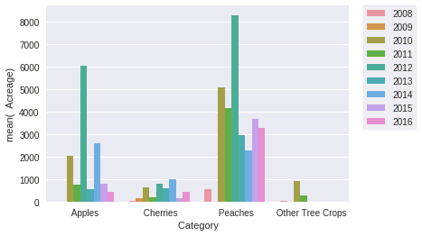

```python
sns.barplot(x=' Category', y='  Acreage', hue='Year', hue_order=[2008,2009,2010,2011,2012,2013,2014,2015,2016], data=col_crop_df_tree_crops)
mpl.pyplot.legend(bbox_to_anchor=(1.05, 1), loc=2, borderaxespad=0.)
```